# Repeated measures intensity

# Low- vs high-repetition training for strength development

## Introduction

What is the recommended intensity for strength development, low- or high-repetition training? Anderson & Kearney (1982) conducted a study on male college students, and found that after a 9 weeks training intervention, 3x6-8 repetition maximum (RM) training, gave a greater increase in 1 RM benchpress compared to 2x30-40 RM training (20 % and 8 %, respectively). However, Stone & Coulter (1994) who conducted a similar 9 weeks training intervention on female collage students, found that both 3x6-8 RM and 1x30-40 RM gave significant pre to post increases in 1 RM in both upper and lower body exercises. In the latter study they could not find a significant difference between the groups after the training intervention. These results suggests that both low- and high-repetition training improves strength measured as 1 RM. To find out if one of the methods are superior to the other and therefore should be recommended, more studies are required.

As a result of this, we wanted to take a closer look at the effects of low- and high-repetition training. The goal of the study is to find out which training intensity, 10 or 30 RM, gives the larger development of strength measured as 1 RM legpress.

#### Question

> What should be the recommended intensity for strength development?

#### Hypothesis

> 10 RM gives a larger development of strength measured as 1 RM legpress, compared to 30 RM

## Methods

#### Study design

To compare the effects of 10 and 30 RM training, the participants of the study were assigned to one of two groups: the 10 RM group or the 30 RM group. Strength was tested as 1 RM legpress and benchpress before (pre), during (mid) and after (post) the training intervention. 27 participants completed the first two tests, and 24 participants completed all three tests.

#### Statistical analysis

We wanted to estimate the difference between the 10 RM and the 30 RM group in 1 RM legpress when controlling for baseline after a strength training intervention. The data set contained several variables, so we first had to reduce our data to only contain our variables of interest: the 1 RM load in legpress at pre-, mid- and post-test for both the 10 RM and 30 RM group. Because we have repeated measures, we have to account for correlated data to avoid that it affects the statistical power. A mixed model accounts for potential differences between the groups at baseline, and was therefore used to estimate the difference in mean between the two groups at both pre-, mid- and post-test. Confidence intervals were used to evaluate the effects. We computed a residual plot to check if our assumptions were met, and the plot indicated that there are no major problems with our model. The data was plotted and presented in a combined plot, where the first one shows changes in strength for each participant and estimated averages in each group at time-points pre, mid and post, and the second shows the average group differences at time-points mid and post (figure 1). The statistics of the estimates is presented in a table (table 1).

## Results

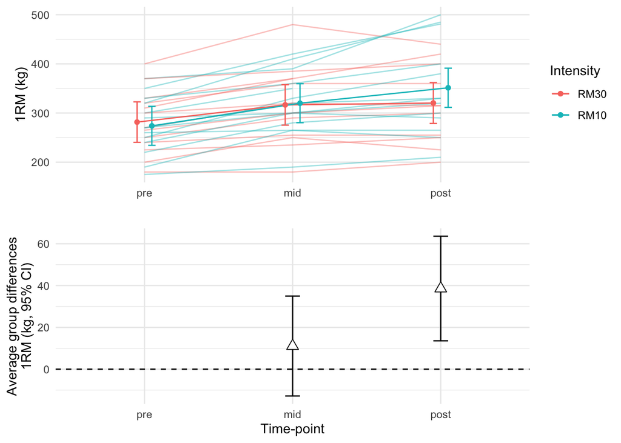

**Figure 1:** Changes in 1 RM legpress for each participant and estimated averages in the 10 RM and 30 RM group at time-points pre, mid and post. Average group differences in 1 RM legpress at time-points mid and post, comparing 10 RM to 30 RM.

Table 1: Coefficient estimates, standard error, t-statistic, lower and upper confidence interval at time-points pre, mid and post in both the 10 RM and 30 RM group.

|  | Estimate | Std. Error | t-value | Lower CI | Higher CI |
| --- | --- | --- | --- | --- | --- |
| (Intercept) | 281.5 | 20.1 | 13.99 | 242.4 | 320.7 |
| timepointmid | 35.0 | 9.0 | 3.90 | 17.8 | 52.2 |
| timepointpost | 38.9 | 9.6 | 4.07 | 20.5 | 57.2 |
| groupRM10 | -7.6 | 27.9 | -0.27 | -62.0 | 46.8 |
| timepointmid:groupRM10 | 11.1 | 12.5 | 0.89 | -12.8 | 35.0 |
| timepointpost:groupRM10 | 38.6 | 13.0 | 2.96 | 13.6 | 63.6 |

## Discussion

As the confidence intervals contained 0, there were no difference between the groups in 1 RM legpress at pre (95% CI: [-62.0, 46.8]), nor at mid (95% CI: [-12.8, 35.0]), respectively. At post-test after the training intervention, there was a difference between the 10 RM group and the 30 RM group, as the confidence interval did not contain 0 (95% CI: [13.6, 63.6]).

This study therefore suggests that 10 RM training gives a larger development of strength measured as 1 RM in legpress, compared to 30 RM training. Our findings indicate that 10 RM should be the recommended intensity for strength development. That high-intensity training may be superior to low-intensity training, is supported by the findings of Anderson & Kearney (1982).

## Appendix R-code

```r
# Chunck to run the code

# Loading needed packages
library(tidyverse)
library(readxl)
library(kableExtra)
library(knitr)
library(broom)
library(lme4)
library(emmeans)
library(cowplot)

# Loading and checking the data
data <- read_xlsx("./data/ten_vs_thirty.xlsx", na = "NA")

# Preparing the data for legpress
leg.data <- data %>%
  filter(!is.na(load)) %>% # Rempving NA from the variable "load"
  filter(exercise == "legpress",           # Chosing legpress
         timepoint %in% c("pre", "mid", "post")) %>%  # Choosing timepoints
  mutate(timepoint = factor(timepoint,
                            levels = c("pre", "mid", "post")),# Fixing the order of timepoint)
         group = factor(group,
                        levels = c("RM30", "RM10"))) # Fixing the order of groups (comparing to 30 RM)

leg.data # Printing the results

# Plotting a figure that shows changes in strength for each participant in each group
leg.figure <- leg.data %>%
  mutate(timepoint = factor(timepoint, levels = c("pre", "mid", "post"))) %>%
  ggplot(aes(timepoint, load, group = subject, color = group)) + # Deciding axis and adding a color to each group
  geom_line() + # Each subject gets a line
  labs(x = "Time-point", y = "1 RM (kg)") +    # Changing the axis´ names
  theme_minimal()                              # Chosing layout

leg.figure # Printing the figure
# Figure: Changes in strength for each participant in both the 10 RM and 30 RM group

# Fitting a mixed model
# Want to compare the two groups and model any differences in change over time.
# A mixed model can account for repeated data by using the subject indicator as a random effect.
# Letting the groups vary from each other with timepoint * group. Let them vary over the timepoints
# Each participant will be compared from their own starting point (intercept).
lmer1 <- lmer(load ~ timepoint * group + (1|subject), data = leg.data)


summary(lmer1) # Printing the results

## Fixed effects from the lmer1 model
# Intercept are the average at pre (10 RM)
# Timepointmid are the difference pre to mid (10 RM)
# Timepointpost are the difference pre to post (10 RM)

# GroupRM10 are the difference between 10 RM and 30 RM at pre
# Timepointmid:groupRM10 are the difference between 10 RM and 30 RM at mid
# Timepointpost:groupRM10 are the difference between 10 RM and 30 RM at post

## Variables of interest
# The difference between the groups when we have controlled for baseline after a trainingintervention
# 11 kg difference between 10 RM and 30 RM at mid
# 38kg difference between 10 RM and 30 RM at post



# Residual plot to check if our assumptions are met
plot(lmer1)
# The residual variation is similar over the range of fitted values, so this is an ok model we can use.


# Model estimates
# Estimated averages at each time-point within each group
est <- emmeans(lmer1, specs = ~ timepoint|group) # Specs specifies what means to calculate

est # Printing the results


# Plotting the model estimates (estimated averages)
# Have to convert the object created with emmeans to a data frame to be able to plot it
est.figure <- est %>%
  data.frame() %>%
  mutate(timepoint = factor(timepoint, levels = c("pre", "mid", "post"))) %>%
  ggplot(aes(timepoint, emmean, group = group, color = group)) +
  geom_errorbar(aes(ymin = lower.CL, ymax = upper.CL), # Represent the 95% CI
                position = position_dodge(width = 0.2), # Moves the errorbars away from each other, same with the lines and points further down
                width = 0.1) + # Decides the width of the errorbars, the same under
  geom_line(position = position_dodge(width = 0.2)) +
  geom_point(position = position_dodge(width = 0.2)) +
  labs(x = "Time-point", y = "1 RM (kg)") + # New labels on the axis
  theme_minimal()
# Figure: Estimated averages in each group at time-points pre, mid and post

est.figure # Printing the figure

## Tips!
# Choosing between SD og CI, CI are preferred when plotting
# Remember to only present a result once! Not the same result in both a table and a figure!


raw.est.figure <- est %>%
  # The model estimates
  data.frame() %>%
  mutate(timepoint = factor(timepoint,
                            levels = c("pre", "mid", "post"))) %>%
  ggplot(aes(timepoint, emmean, group = group, color = group) ) +

  # Adding raw data
  geom_line(data = leg.data, aes(timepoint, load, group = subject, color = group),
            alpha = 0.4) + # Add transparency to individual lines
  geom_errorbar(aes(ymin = lower.CL, ymax = upper.CL),
                position = position_dodge(width = 0.2),
                width = 0.1) +
  geom_line(position = position_dodge(width = 0.2)) +
  geom_point(position = position_dodge(width = 0.2)) +
  labs(x = "", y = "1RM (kg)",
       color = "Intensity") + # New labels on the axis
  # Removing text and indicators on the x-axis as we are going to combine this plot with another, and then we use the text and indicators in that plot
  theme(axis.text.x = element_blank(),
        axis.title.x = element_blank()) +
  theme_minimal()
# Figure: Changes in strength for each participant and estimated averages in each group at time-points pre, mid and post


raw.est.figure # Printing the figure



# Saving the confidence intervals
# Getting the 95% CI from each model coefficient
conf_intervals <- confint(lmer1)
conf_intervals
# CI at post do not contain 0. Ergo, we have proof against the null hypothesis that says that there are no difference between the groups. There is a difference!
# Present random effects as well?

# Saving the regression coefficients
# Getting the estimates of the interaction coefficients from the model
coefs <- summary(lmer1)$coef
coefs

# Using cbind (column bind) to combine the two data frames into one data frame
coef_summary <- cbind(coefs, data.frame(conf_intervals)[3:8, ])
coef_summary

# Printing a table using kable()
coef.table <- coef_summary %>%
  kable(col.names = c("Estimate", "Std. Error", "t-value", "Lower CI", "Higher CI"), # Column names
        digits = c(1, 1, 2, 1, 1),# Deciding how many decimals at each value
        caption = "**Table 1:** Coefficient estimates, standard error, t-statistic, lower and upper confidence interval at time-points pre, mid and post in both the 10 RM and 30 RM group.")
# Table: Coefficient estimates, standard error, t-statistic, lower and upper confidence interval

coef.table   # Printing the table



# Plot to show "What should be the recommended intensity for strength development?"
# Interested in the estimates "timepoint:groupRM10" and "timepointpost:groupRM10"

# Reducing the data frame and plotting it to show estimated differences between groups at mid and post after accounting for baseline differences
est.diff.figure <- coef_summary %>%
  mutate(coef = rownames(.)) %>%
  # Filter only the interaction variables
  filter(coef %in% c("timepointmid:groupRM10", "timepointpost:groupRM10")) %>%
  # Making a "timepoint" variable to represent the "leg.data" data set.
  mutate(timepoint = gsub("timepoint", "", coef),
         timepoint = gsub(":groupRM10", "", timepoint)) %>%
  # Adding a row so that timepoint = "pre" is represented
  add_row(timepoint = "pre", coef = "pre") %>%
  # Fixing the order of the time variable
  mutate(timepoint = factor(timepoint, levels = c("pre", "mid", "post"))) %>%
  # Creating the plot
  ggplot(aes(timepoint, Estimate)) +
  # Adding a line indicating zero geom_hline (horizontal line)
  geom_hline(yintercept = 0, lty = 2) +
  # Adding errorbars and points
  geom_errorbar(aes(ymin = X2.5.., ymax = X97.5..), width = 0.1) +
  geom_point(shape = 24, size = 3, fill = "white") +
  # Changing axis titles and title in the legend
  labs(x = "Time-point", y = "Average group differences\n1RM (kg, 95% CI)",
       color = "Intensity") +
  theme_minimal()

est.diff.figure # Printing the figure
# Figure: Average group differences in 1 RM legpress at mid and post, comparing 10 RM to 30 RM.

# Answer to our question: 10 RM should be the recommended intensity
# The points show the difference between the groups at the different time-points, comparing 10 RM to 30 RM.


# Combining the plots to one plot
# Using "raw.est.figure" and "est.diff.figure"
figure1 <- plot_grid(raw.est.figure, est.diff.figure, ncol = 1,
          # Aligning vertically so that the x axis matches
          align = "v",
          # Setting alignment so that axis align both on the left (l) and right (r) axis
          axis = "lr")

figure1 # Printing the figure
# Figure 1: Changes in 1 RM legpress for each participant and estimated averages in each group at time-points pre, mid and post. Average group differences in 1 RM legpress at time-points mid and post.
```

## References

Anderson, T., and J. T. Kearney. 1982. “Effects of Three Resistance Training Programs on Muscular Strength and Absolute and Relative Endurance.” *Research Quarterly for Exercise and Sport* 53 (1): 1–7. https://doi.org/10.1080/02701367.1982.10605218.

Stone, W. J., and S. P. Coulter. 1994. “Strength/Endurance Effects from Three Resistance Training Protocols with Women.” *The Journal of Strength & Conditioning Research* 8 (4): 231–34. https://journals.lww.com/nsca-jscr/Fulltext/1994/11000/Strength_Endurance_Effects_From_Three_Resistance.5.aspx.